# How real is Racing Louisville?: Part 1

7/15/2025

[Back to home](https://ajsportstat.github.io/nwsl-2025)

The 2025 NWSL season has come with a lot of surprises. The San Diego Wave and the Portland Thorns are both massively out-performing preseason predictions, while Gotham FC, the North Carolina Courage, and Bay FC are all finishing out the first half of the season lower than many would have expected. All of these teams have ended up in many different table positions, however, but Racing Louisville has quite literally never finished a season outside of 9th place. Their current position of 7th place (just 5 points shy of 2nd), along with their most recent statement victory over 2024 NWSL champions and shield winners Orlando Pride, has had me wondering just how real this team really is, and whether this will be the season they finally finish above 9th and make it into the playoffs.

A friend of mine once told me they wished they saw more hypothesis testing in sports data analysis, and this is the perfect opportunity for me to fulfill their wish. I’m going to turn to hypothesis testing to see just how much of this perceived change in Racing Louisville that we can read into, and whether we can expect a drop-off in the back half of the season.

A quick explainer of hypothesis testing: a hypothesis test is a statistical procedure that uses data to test hypotheses about populations. There are several types of hypothesis tests, but for the purposes of this piece, I will be focusing on means comparison, which as you might have guessed, tests hypotheses about the difference in means between two groups. Every hypothesis test consists of a null hypothesis, which is that there is no change or effect observed, and an alternative hypothesis, which can be two-tailed (i.e. there is a non-zero change or effect) or one-tailed (i.e. that the change is either greater than or less than zero). My goal here is to figure out whether this year’s Louisville side is better than last year’s, so I will be doing one-tailed tests.

There are a three important statistics that will come out of each test: an actual difference in means, a t statistic (which is sort of an estimate of the true difference between the means that also takes into account variability within a sample), and a p-value (which is essentially a measure of how likely it is that the null hypothesis is true). So, a lower p-value in this case would indicate a higher likelihood that there is a statistically significant difference between the means. Typically p-values under 0.05 are considered a statistically significant change, and in some cases p-values up to 0.10 are accepted. I’ll go into this on a case-by-case basis.

This is going to be a two-part series: in the first, I will be comparing Racing Louisville’s statistics from this season to their statistics from last season, and in the second I will be comparing their statistics from this season to those of the Seattle Reign, who sit 1 place and 1 point above Louisville in NWSL standings halfway through the 2025 season.

This season, Louisville has played each opponent once so far. In order to keep things fair, I will be comparing this season against the 13 matches from 2024 where Racing Louisville played each opponent for the first time, so that strength of schedule is not a factor–this is what I mean when I refer to “this point last season.” I chose not to do paired tests (in this case, this would mean comparing Louisville’s performance against the Wave this season vs. their first performance against the Wave last season, for example) because teams change a lot season over season and so this didn’t feel like a particularly useful data point.

**Realm 1: Offense**

The first thing I’m going to look at is whether the team is better offensively than they have been in the past. I’m going to look at a few different metrics here: goals, xG, shots/shots on target, touches in the final third, and attempted/successful take-ons.

*Hypothesis test 1: Goals scored*

The idea here is Louisville would definitively be a better team offensively if they were scoring more goals.

Null hypothesis: Louisville is not scoring more goals than they were at this point last season.

Alternative hypothesis: Louisville is scoring more goals than they were at this point last season.

So the funny thing here is Louisville has scored the exact same number of goals.

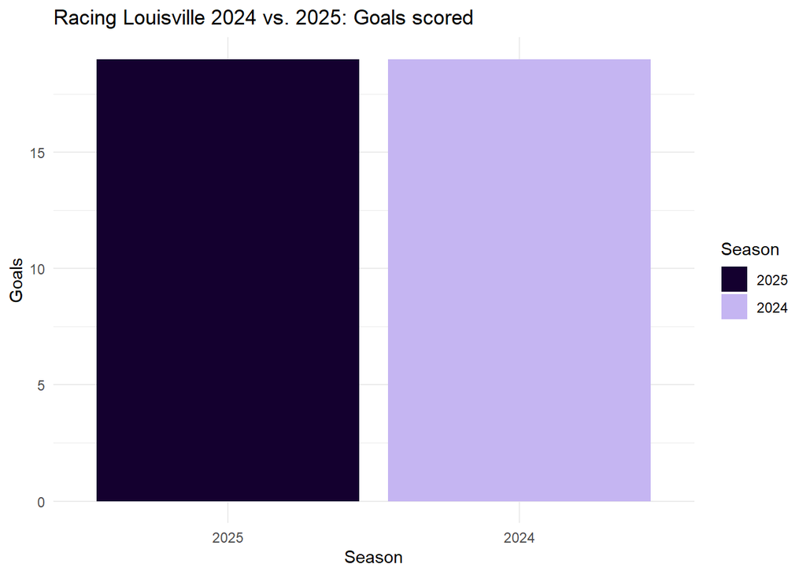

Which means they’ve also scored the same number of goals per game. Regardless, I ran a t-test on these two datasets and got the following results.

| Dependent Variable | t | df | p | d | 95% CI |
| --- | --- | --- | --- | --- | --- |
| Goals | 0.00 | 23.00 | .500 | 0.00 | [-0.77, 0.77] |

A quick note on how to interpret these results: “t” refers to the t statistic I discussed earlier; “df” refers to “degrees of freedom”, which is a measure used to calculate significance that you don’t need to worry about; “p” is the p-value, aka what we will be using to determine statistical significance; “d” refers to Cohen’s d, a measure of the difference between the group means that is essentially standardized to be the same “unit” for all variables (0.2 is a small effect, 0.5 is a medium effect, and 0.8 is a large effect); and “95% CI” refers to a “95% confidence interval”–in this case, that means that the model is 95% confident that the true difference between these two groups lies within these two numbers, but the range has to be quite big to encapsulate 95% certainty, so it’s not of much help to us here.

This was not the strongest test to start. So far Louisville does not seem better, but luckily we have a lot more measures to look at.

*Hypothesis test 2: xG*

Null hypothesis: Louisville is not generating more xG than they were at this point last season.

Alternative hypothesis: Louisville is generating more xG than they were at this point last season.

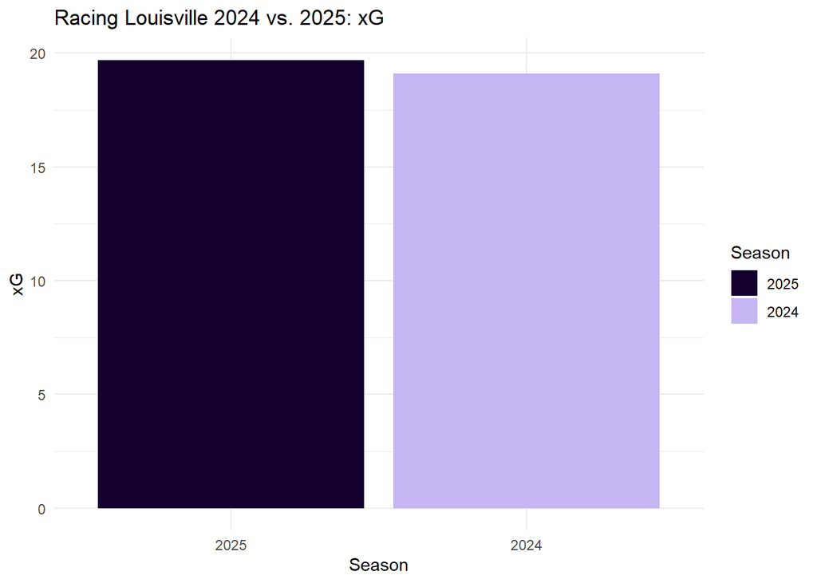

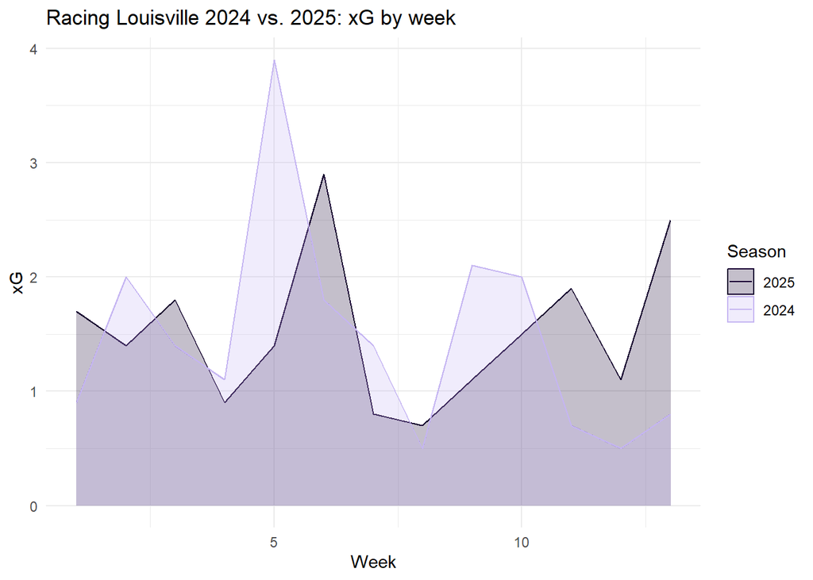

If we look at the raw numbers, Louisville has generated a bit more xG this season than the last (and also is creating that xG a bit more consistently, with higher lows and lower highs), but it amounts to an average of 0.05 more xG per game. Is that statistically significant?

| Dependent Variable | t | df | p | d | 95% CI |
| --- | --- | --- | --- | --- | --- |
| xG | 0.15 | 21.48 | .442 | 0.06 | [-0.71, 0.83] |

So the answer is no. But that doesn’t change the fact that Louisville is generating more xG so far this season, as little as it may be. Baby steps. I’m going to choose how to read into this once I have the context of all the other offensive variables.

*Hypothesis test 3: Shots*

Null hypothesis: Louisville is not taking more shots than they were at this point last season.

Alternative hypothesis: Louisville is taking more shots than they were at this point last season.

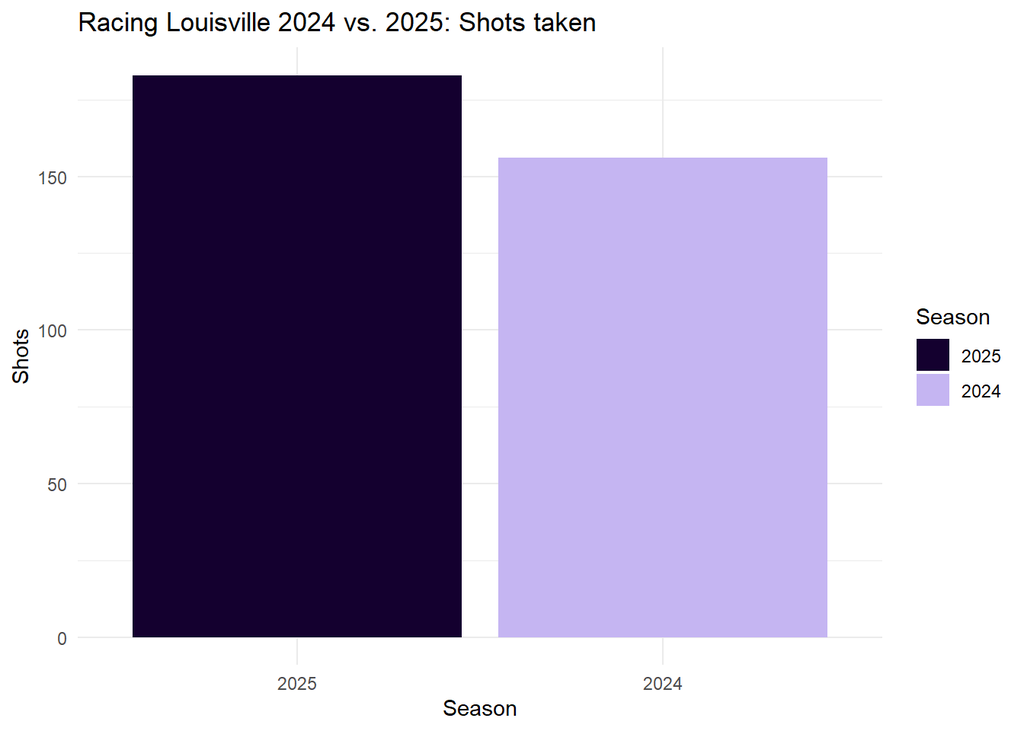

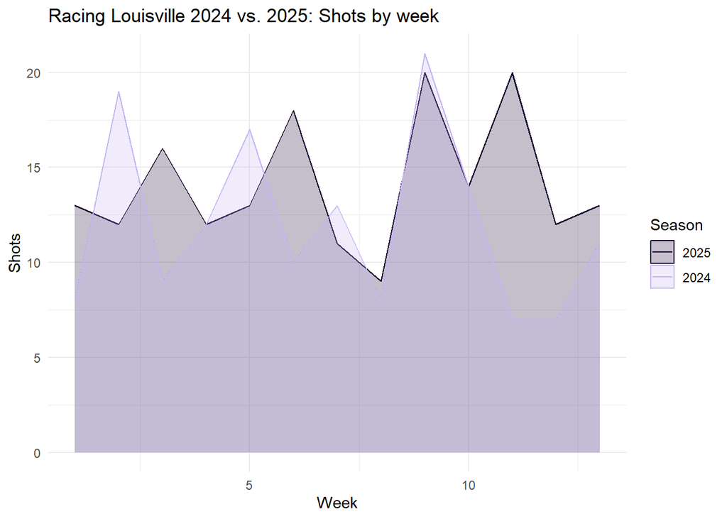

Racing Louisville appear to be taking more shots, averaging 2.1 more shots per game this season.

| Dependent Variable | t | df | p | d | 95% CI |
| --- | --- | --- | --- | --- | --- |
| Shots | 1.30 | 22.14 | .103 | 0.51 | [-0.28, 1.29] |

Unfortunately, 99 out of 100 statisticians wouldn’t consider this statistically significant, with 0.10 usually being the highest p-value threshold. But life isn’t black and white, so I’m going to call this one partially statistically significant, because a p-value of 0.103 with a sample size this small is nothing to sneeze at. Because it’s only 0.003 above the standard threshold, I’m going to be bold and say that **Racing Louisville is taking more shots this season than last**. Let’s look at the rest of the results before deciding what this means for the team though.

*Hypothesis test 4: Shots on target*

Null hypothesis: Louisville’s shot on target percent is not higher than it was at this point last season.

Alternative hypothesis: Louisville’s shot on target percent is higher than it was at this point last season.

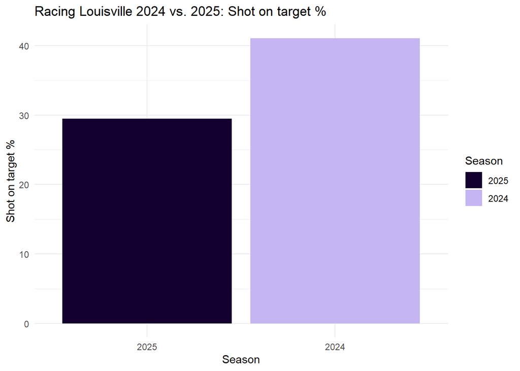

This one is pretty cut and dry–Louisville has a lower shot on target percent this year than they did last year. For fun, here are the t-test results:

| Dependent Variable | t | df | p | d | 95% CI |
| --- | --- | --- | --- | --- | --- |
| Shot_on_Target_Pct | -1.93 | 23.89 | .967 | -0.76 | [-1.55, 0.05] |

Yeah, so it’s actually statistically significant in the other direction. That is, **Racing Louisville has a lower percentage of shots on target this season than last**.

*Hypothesis test 5: xG per shot*

Null hypothesis: Louisville is not creating more xG per shot than they were at this point last season.

Alternative hypothesis: Louisville is creating more xG per shot than they were at this point last season.

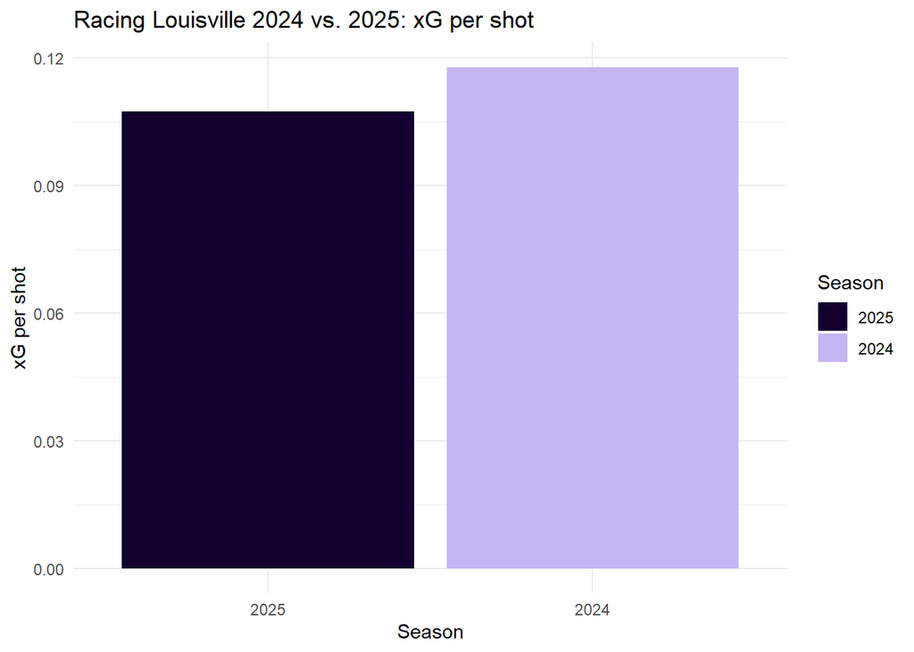

| Dependent Variable | t | df | p | d | 95% CI |
| --- | --- | --- | --- | --- | --- |
| xG_per_Shot | -0.62 | 22.79 | .730 | -0.24 | [-1.01, 0.53] |

It’s not statistically significant in either direction, but on the whole we’re seeing less xG per shot from Racing Louisville this season than last.

*Hypothesis test 6: Final third touches*

Null hypothesis: Louisville has not had more touches in the final third than they did at this point last season.

Alternative hypothesis: Louisville has had more touches in the final third than they did at this point last season.

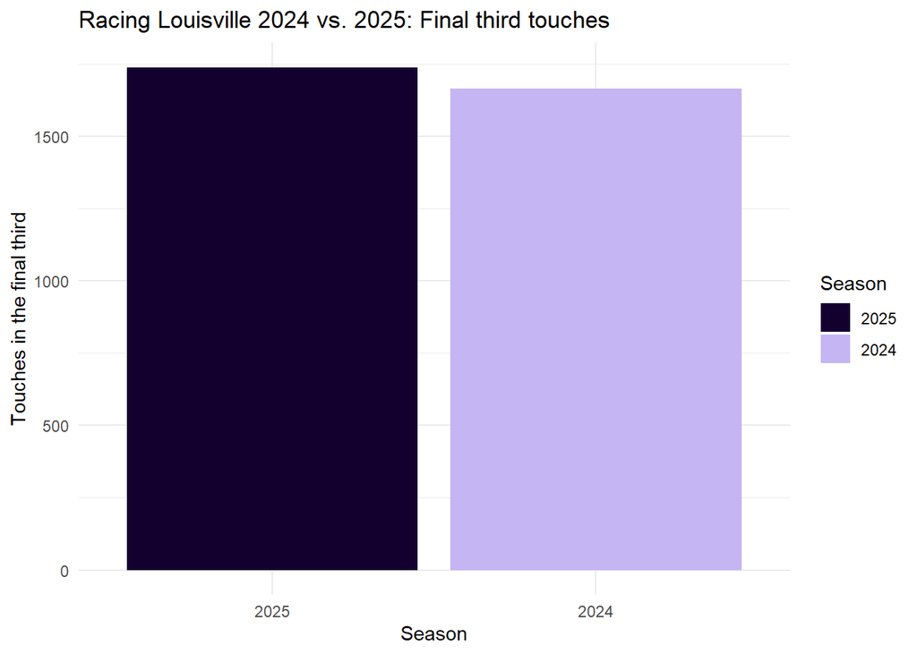

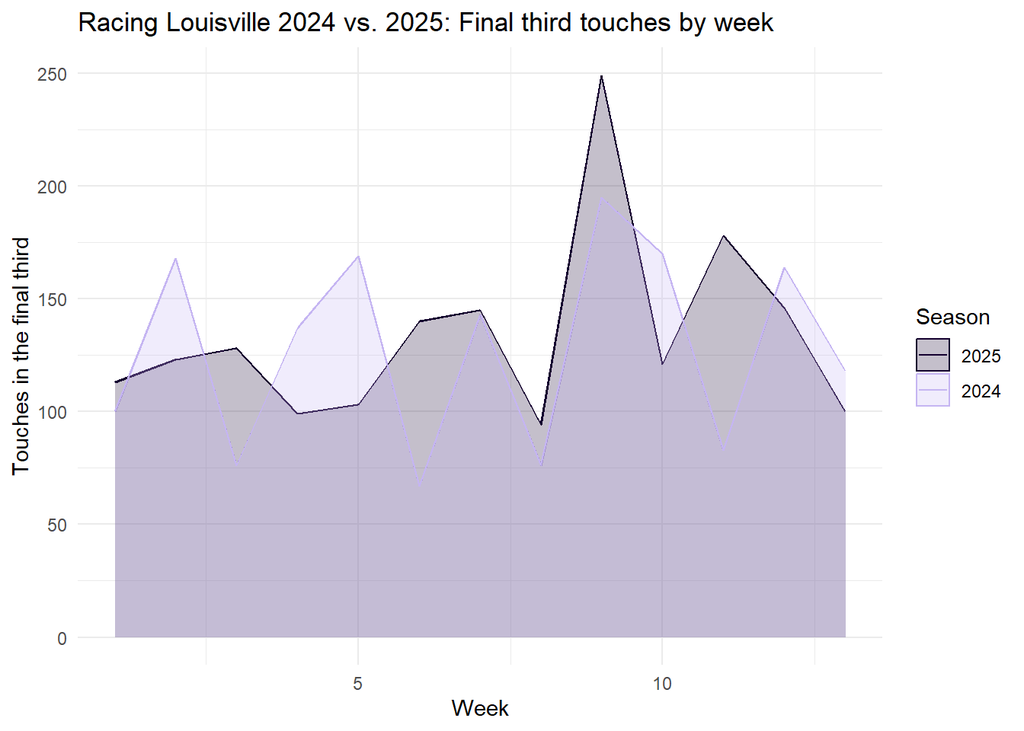

This is looking promising–they have more touches, and they also seem to do so a lot more consistently this season.

| Dependent Variable | t | df | p | d | 95% CI |
| --- | --- | --- | --- | --- | --- |
| Final_Third_Touches | 0.33 | 23.95 | .371 | 0.13 | [-0.64, 0.90] |

However, it is not enough to be statistically significant. Moving on.

*Hypothesis test 7: Take-ons*

Null hypothesis: Louisville is not attempting more take-ons than they were at this point last season.

Alternative hypothesis: Louisville is attempting more take-ons than they were at this point last season.

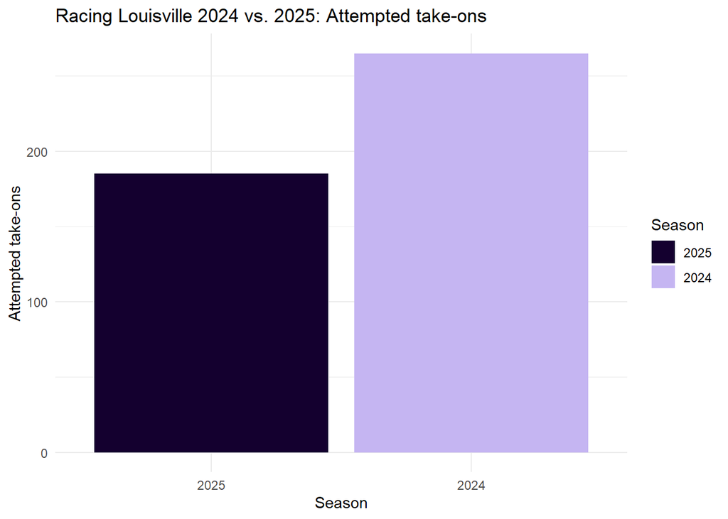

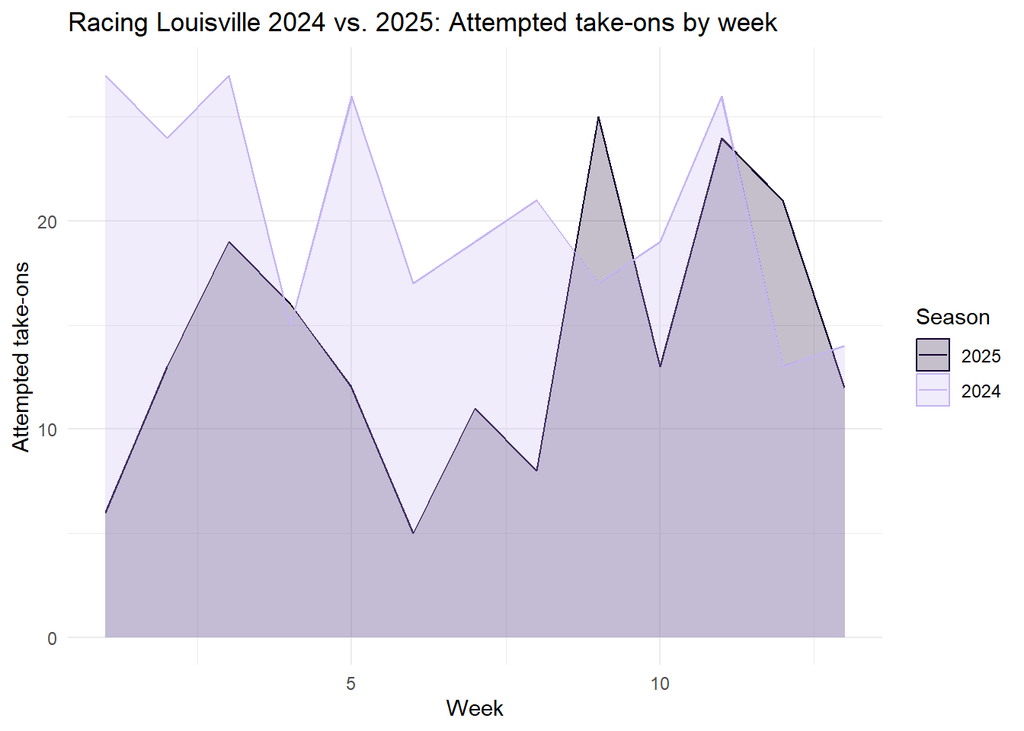

Another instance where Louisville is worse off this season than they were last season.

| Dependent Variable | t | df | p | d | 95% CI |
| --- | --- | --- | --- | --- | --- |
| Attempted_Takeons | -2.70 | 22.84 | .994 | -1.06 | [-1.87, -0.22] |

In fact, it’s statistically significant that **Racing Louisville is attempting fewer take-ons than they were at this point last season**. That’s not necessarily a sign of a worse offense–they could be playing a different style that is ultimately getting them more goals and xG.

*Hypothesis test 8: Take-on success rate*

Null hypothesis: Louisville does not have a higher take-on success rate than they did at this point last season.

Alternative hypothesis: Louisville has a higher take-on success rate than they did at this point last season.

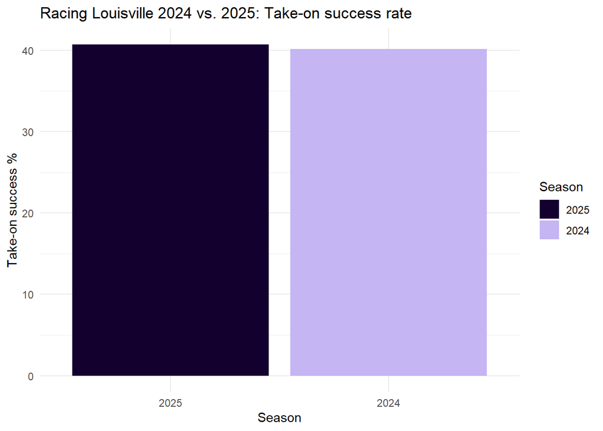

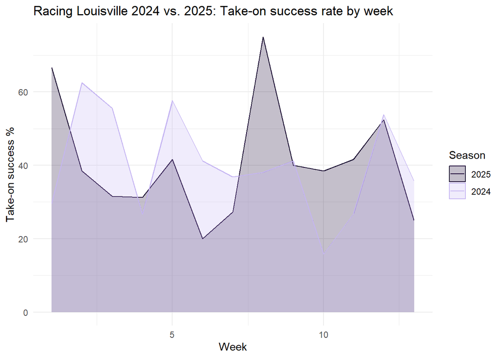

Racing Louisville has a slightly higher take-on success rate this season.

| Dependent Variable | t | df | p | d | 95% CI |
| --- | --- | --- | --- | --- | --- |
| Successful_Takeon_Pct | 0.10 | 23.60 | .460 | 0.04 | [-0.73, 0.81] |

But just barely, and it’s not enough to be statistically significant.

My overall takeaway is that Louisville is overall doing slightly better offensively this season, but really the only thing we should be reading into is that they are taking more shots. This is still pretty big: being able to get into a position to take a shot is a win, and theoretically the more time they are spending taking shots, the less time their opponents have to take shots of their own. Let’s see if that last bit is actually true, though.

**Realm 2: Defense**

I also want to see if Louisville is a better defensive team than they were last season. The most important thing when it comes to defense is the number of goals allowed. In addition to that, I will be looking at xG and PSxG allowed, shots/shots on target allowed, tackle success rate, loose ball recoveries, times dispossessed, and errors leading to an opponent’s shot. I also want to understand if there is something fundamentally different about how Louisville is playing this season, and while data alone is far from a perfect way of answering that question, I’m going to try by looking at if there’s a difference in where on the pitch this team is winning (and therefore attempting) tackles this season.

*Hypothesis test 1: Goals allowed*

Null hypothesis: Louisville is not conceding fewer goals than they were at this point last season.

Alternative hypothesis: Louisville is conceding fewer goals than they were at this point last season.

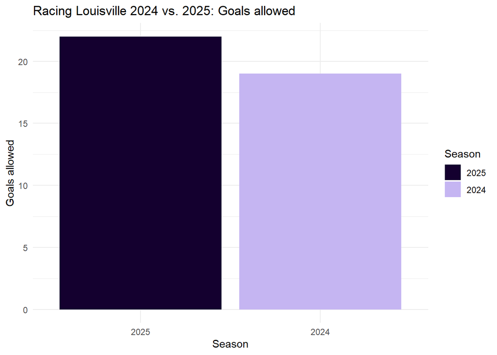

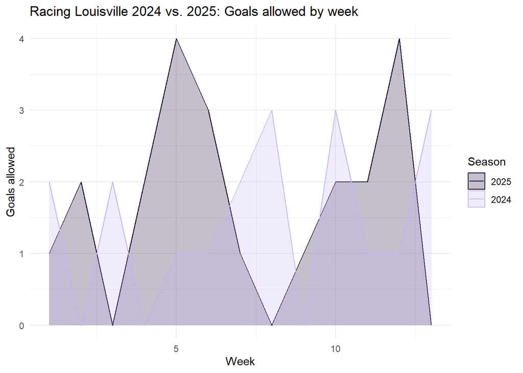

Louisville has definitely allowed more goals this season than last (and has had some very high highs), but let’s look at the t-test results regardless.

| Dependent Variable | t | df | p | d | 95% CI |
| --- | --- | --- | --- | --- | --- |
| Goals_allowed | 0.47 | 23.09 | .678 | 0.18 | [-0.59, 0.95] |

Based on goals allowed alone, Louisville is a little worse off this season. Not off to a great start, but they could have been getting unlucky. Let’s look at a few more variables.

*Hypothesis test 2: xG allowed*

Null hypothesis: Louisville is not conceding less xG than they were at this point last season.

Alternative hypothesis: Louisville is conceding less xG than they were at this point last season.

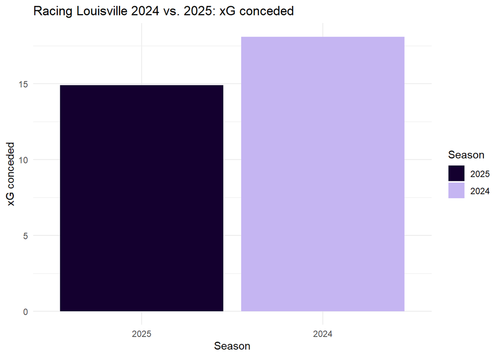

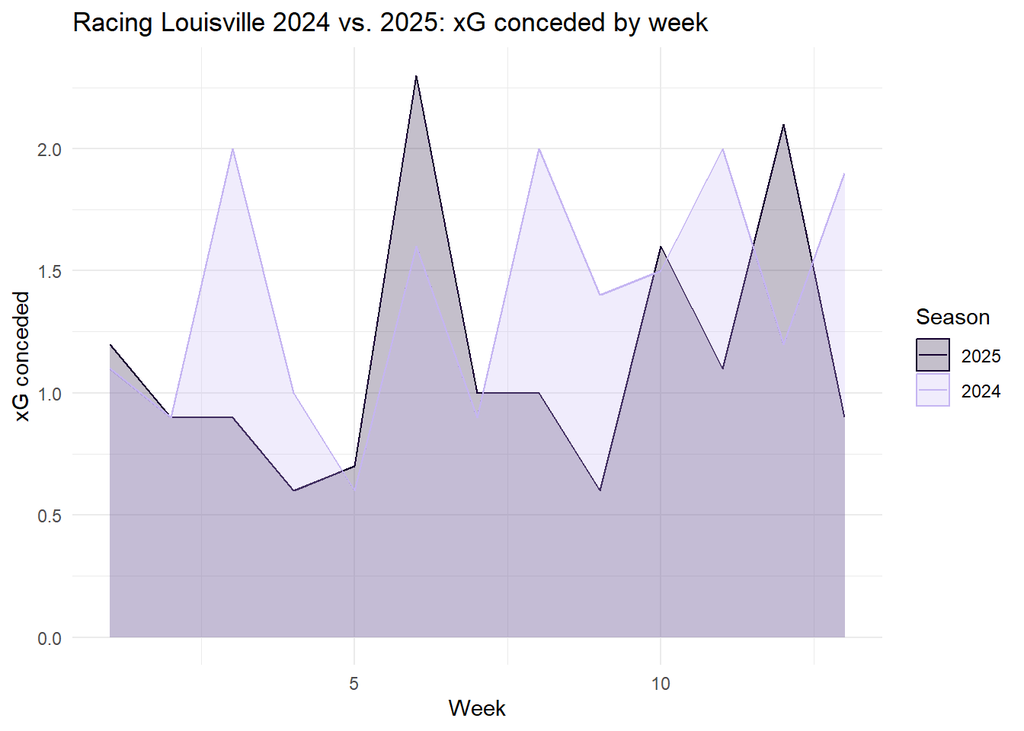

Okay, they seem to be allowing less xG! Let’s look at the t-test results.

| Dependent Variable | t | df | p | d | 95% CI |
| --- | --- | --- | --- | --- | --- |
| xG_allowed | -1.23 | 23.74 | .116 | -0.48 | [-1.26, 0.30] |

Not terrible. It’s 0.016 off from being statistically significant so you know what, I’ll allow it. **Racing Louisville is conceding less xG this season than they were at this point last season**.

*Hypothesis test 3: PSxG allowed*

Null hypothesis: Louisville is not conceding less PSxG than they were at this point last season.

Alternative hypothesis: Louisville is conceding less PSxG than they were at this point last season.

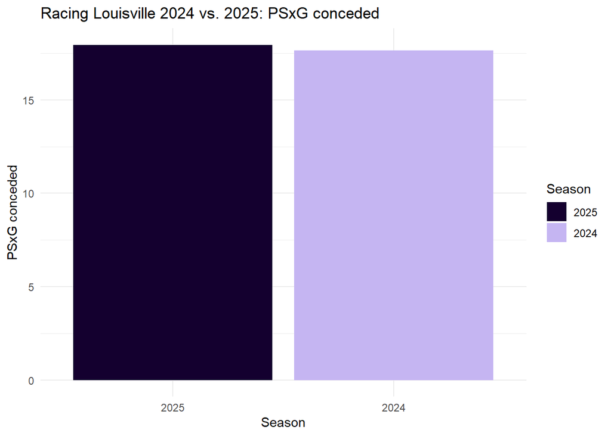

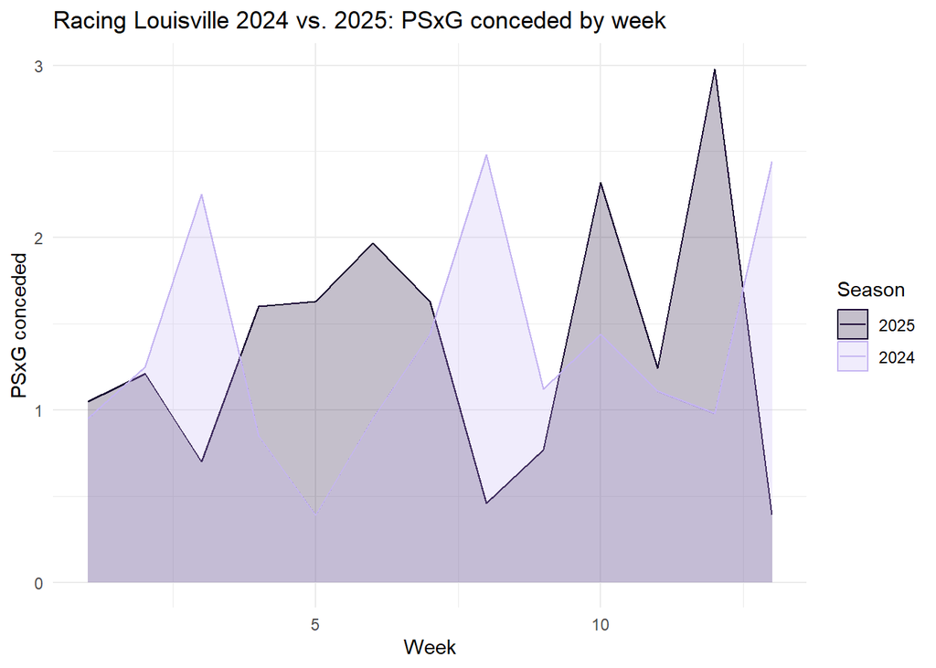

Ah and here we start to see the answer of how Louisville has conceded so many more goals than their xG suggests–they seem to be allowing their opponents to take quality shots. It’s worth noting that it’s hard to tell how much of this is bad luck vs. bad defending from this one data point alone. Let’s see what the t-test makes of this.

| Dependent Variable | t | df | p | d | 95% CI |
| --- | --- | --- | --- | --- | --- |
| PSxG_allowed | 0.08 | 23.49 | .533 | 0.03 | [-0.74, 0.80] |

With a p-value just 0.033 off from being 0.5, the model doesn’t make much of Louisville’s PSxG this season vs. last. But let’s take a look at the PSxG to xG ratio.

| Dependent Variable | t | df | p | d | 95% CI |
| --- | --- | --- | --- | --- | --- |
| PSxG_per_xG | 1.48 | 17.49 | .922 | 0.58 | [-0.21, 1.36] |

This test thinks Louisville’s PSxG to xG ratio is significantly higher than last season’s. This is a statistic I just made up, however, so we don’t have to read too much into it. Just know that for some reason, whether that be bad luck or systematically giving their opponents the space to create beautiful shots out of pretty low probability chances, Racing Louisville is conceding a lot more PSxG than you would expect.

*Hypothesis test 4: Shots allowed*

Null hypothesis: Louisville is not allowing fewer shots than they were at this point last season.

Alternative hypothesis: Louisville is allowing fewer shots than they were at this point last season.

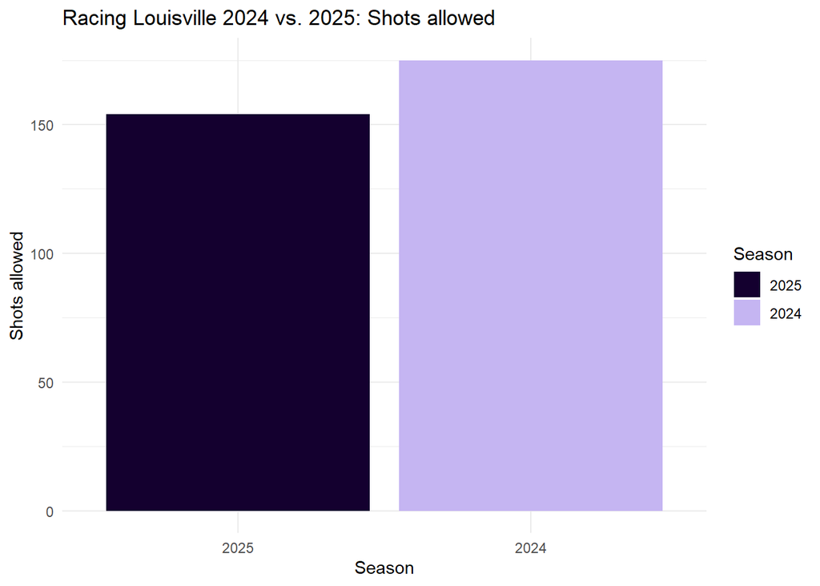

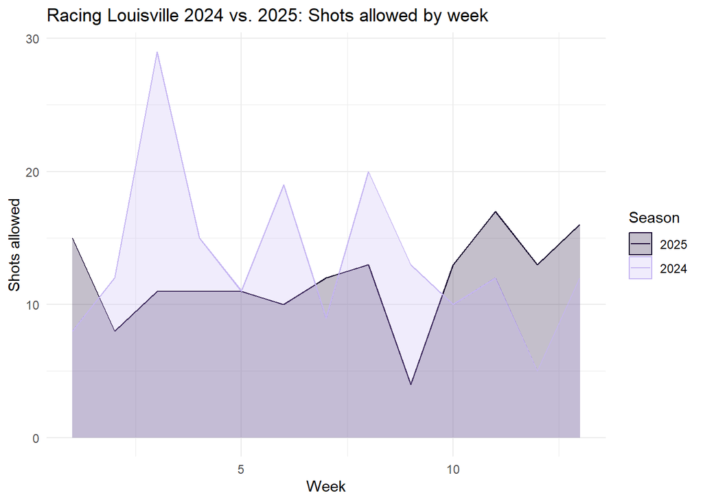

Certainly looks like they’re allowing fewer shots!

| Dependent Variable | t | df | p | d | 95% CI |
| --- | --- | --- | --- | --- | --- |
| Shots_allowed | -0.82 | 18.63 | .211 | -0.32 | [-1.09, 0.46] |

And the t-test almost agrees. It would be kind of egregious to call a p-value of 0.211 statistically significant, but this is definitely something. I’ll give them half credit.

Let’s take a look at the xG per shot they’re conceding though.

| Dependent Variable | t | df | p | d | 95% CI |
| --- | --- | --- | --- | --- | --- |
| xG_per_Shot | -0.65 | 23.99 | .262 | -0.25 | [-1.02, 0.52] |

Also not too shabby here! Good job Louisville. Expected values suggest they’re doing well defensively, even if the actual goals allowed doesn’t quite match that (yet).

*Hypothesis test 5: Shots on target allowed*

Null hypothesis: Louisville is not allowing fewer shots on target than they were at this point last season.

Alternative hypothesis: Louisville is allowing fewer shots on target than they were at this point last season.

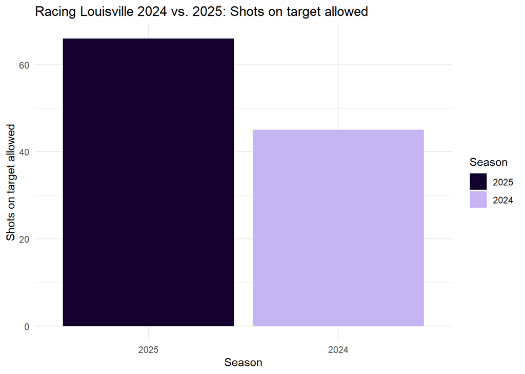

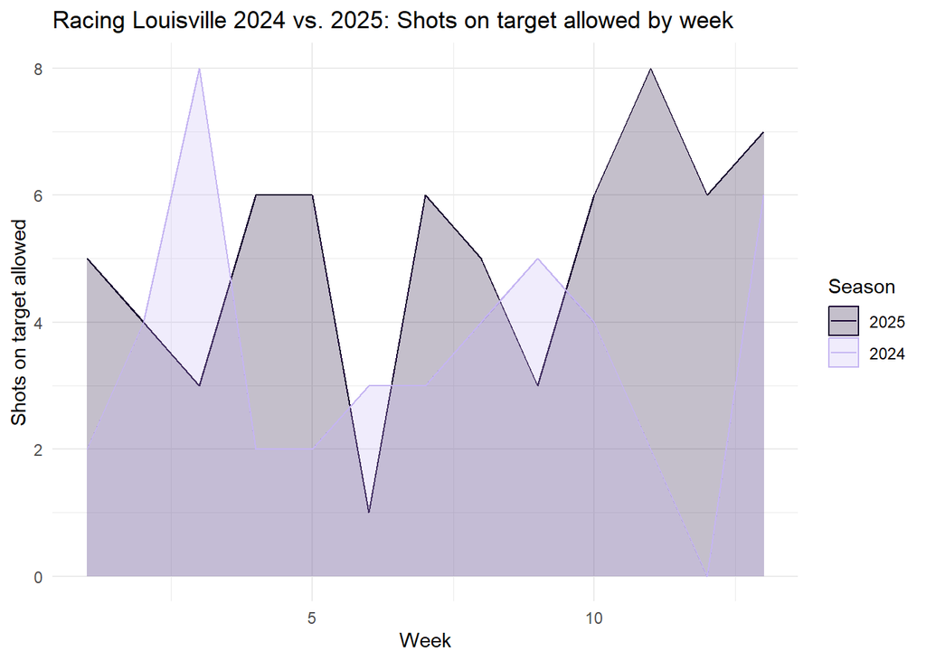

Mmm. This is not good.

| Dependent Variable | t | df | p | d | 95% CI |
| --- | --- | --- | --- | --- | --- |
| Shots_on_Target_allowed | 2.08 | 23.81 | .976 | 0.82 | [0.01, 1.61] |

Yeah not good at all. Per this test, **Racing Louisville is allowing significantly more shots on target this season than last season**, despite allowing fewer shots overall.

*Hypothesis test 6: Tackle win rate*

Null hypothesis: Louisville is not winning a higher percentage of their tackles than they were at this point last season.

Alternative hypothesis: Louisville is winning a higher percentage of their tackles than they were at this point last season.

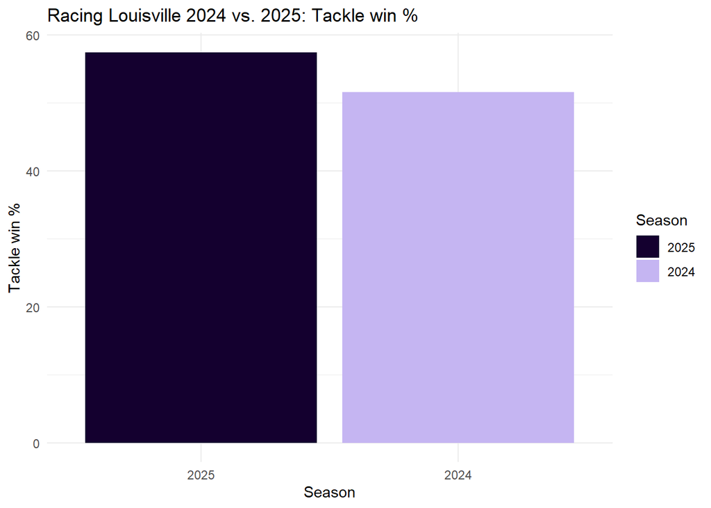

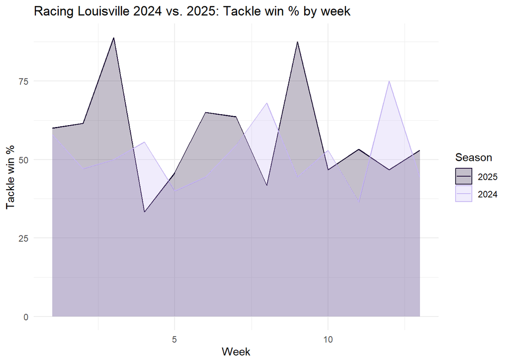

Looking better…

| Dependent Variable | t | df | p | d | 95% CI |
| --- | --- | --- | --- | --- | --- |
| Tackle_Win_Pct | 1.07 | 20.84 | .148 | 0.42 | [-0.36, 1.19] |

Not a terrible p-value there. I’ll call this another half credit.

*Hypothesis test 7: Ball recoveries*

Null hypothesis: Louisville is not recovering more loose balls than they were at this point last season.

Alternative hypothesis: Louisville is recovering more loose balls than they were at this point last season.

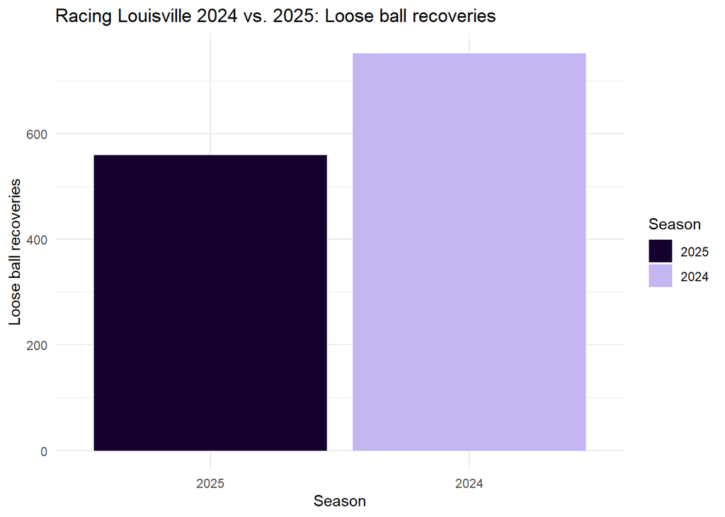

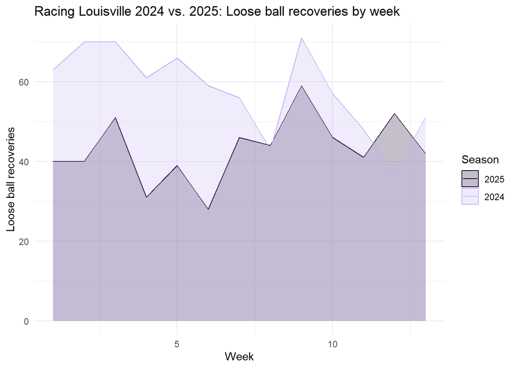

It seems like they’re definitively doing worse.

| Dependent Variable | t | df | p | d | 95% CI |
| --- | --- | --- | --- | --- | --- |
| Recoveries | -3.95 | 22.60 | 1.00 | -1.55 | [-2.42, -0.65] |

Yep. You rarely ever see p-values like that. This is not a bad thing though–the best defenses do not hinge entirely on their ability to recover loose balls. It’s definitely a bonus though.

*Hypothesis test 8: Dispossessed*

This one is a little more important than loose ball recoveries.

Null hypothesis: Louisville is not being dispossessed less than they were at this point last season.

Alternative hypothesis: Louisville is being dispossessed less than they were at this point last season.

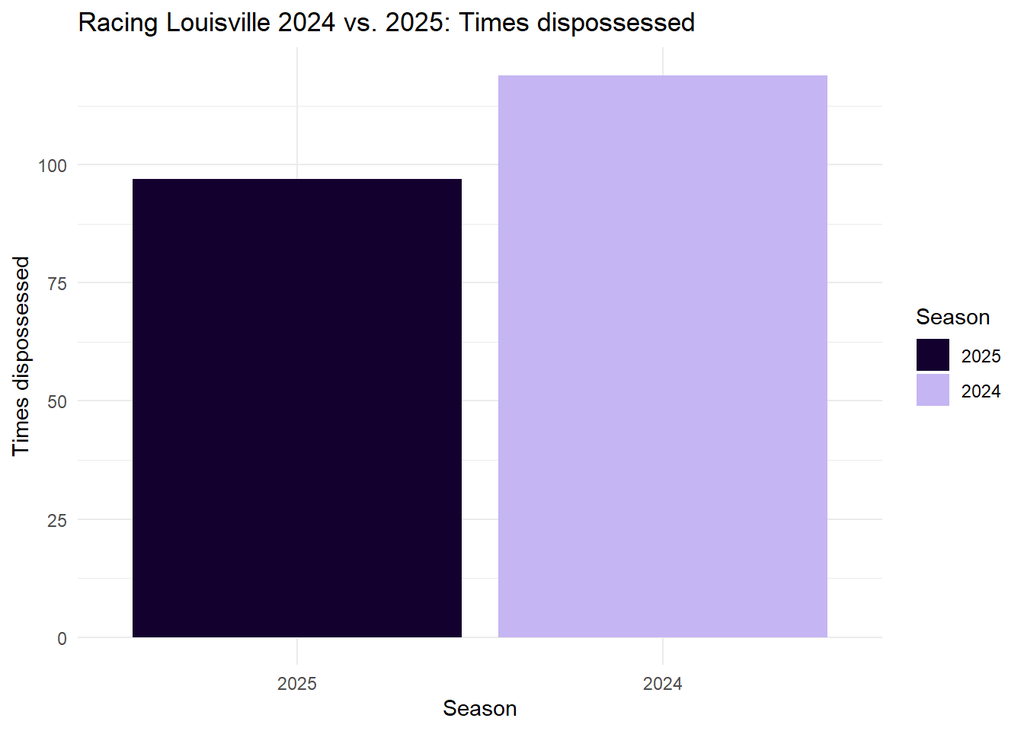

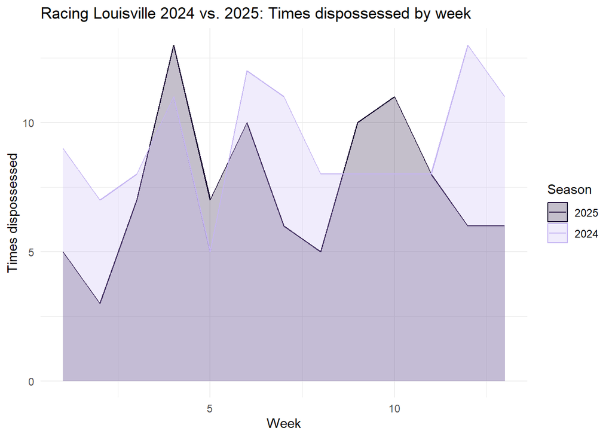

This is good!

| Dependent Variable | t | df | p | d | 95% CI |
| --- | --- | --- | --- | --- | --- |
| Dispossessed | -1.69 | 22.95 | .053 | -0.66 | [-1.45, 0.14] |

*Hypothesis test 9: Errors*

Null hypothesis: Louisville does not have fewer errors leading to opponents’ shots than they did at this point last season.

Alternative hypothesis: Louisville does have fewer errors leading to opponents’ shots than they did at this point last season.

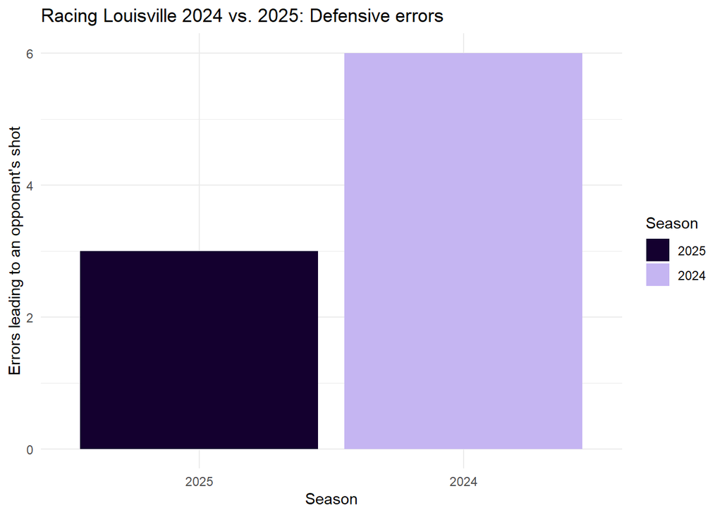

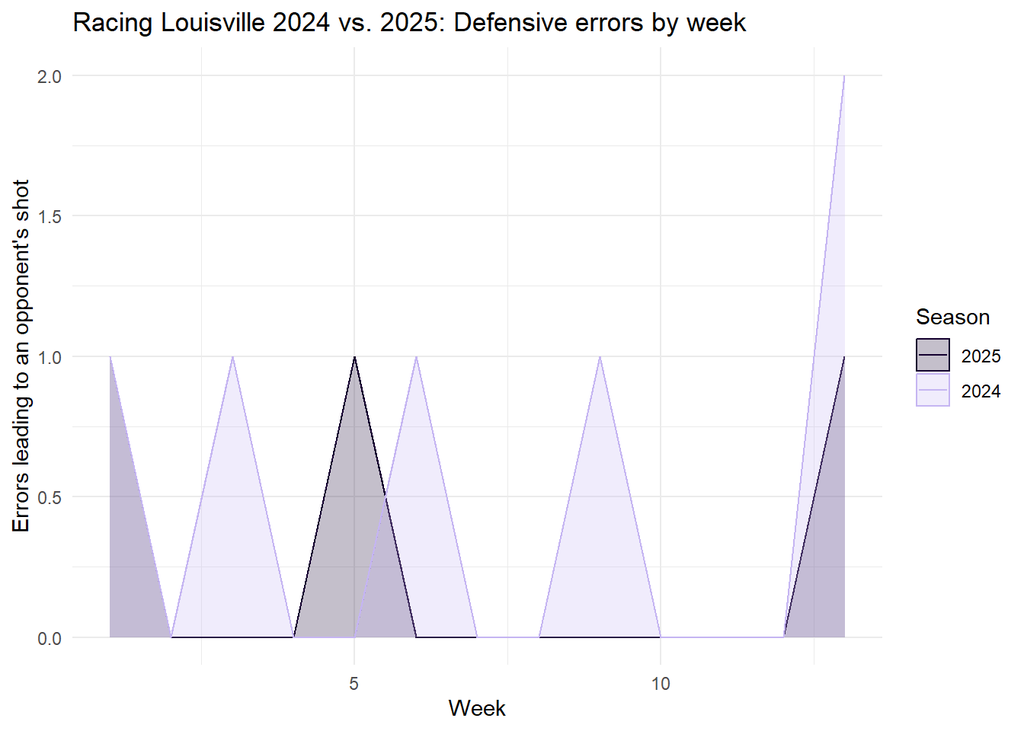

I am once again optimistic.

| Dependent Variable | t | df | p | d | 95% CI |
| --- | --- | --- | --- | --- | --- |
| Errors | -1.05 | 20.86 | .153 | -0.41 | [-1.19, 0.37] |

Not quite statistically significant but still significant in my heart. Half credit.

*Hypothesis test 10: Where on the pitch are Louisville winning tackles?*

Null hypothesis: Louisville is not winning tackles higher up the pitch than they were last season.

Alternative hypothesis: Louisville is winning tackles higher up the pitch than they were last season.

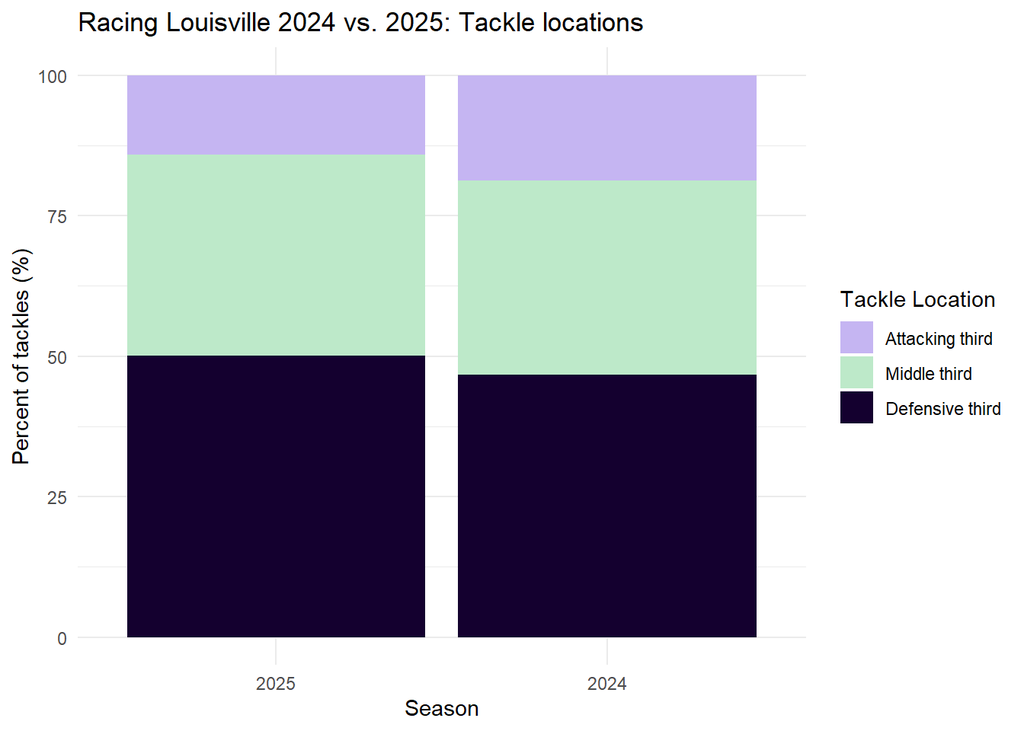

It seems like Louisville’s tackles are further down the pitch this season, which could be indicative of a defense that is more reactive as opposed to an offense that is more proactive, but let’s see what the t-tests say.

| Dependent Variable | t | df | p | d | 95% CI |
| --- | --- | --- | --- | --- | --- |
| Attacking_Third_Tackles | -1.12 | 23.36 | .863 | -0.44 | [-1.21, 0.34] |

First, it looks like Louisville is winning a smaller share of its tackles in the attacking third this season, almost enough to be statistically significant.

| Dependent Variable | t | df | p | d | 95% CI |
| --- | --- | --- | --- | --- | --- |
| Middle_Third_Tackles | 0.25 | 23.67 | .403 | 0.10 | [-0.67, 0.86] |

Louisville is winning slightly more tackles in the middle third this season, but just slightly.

| Dependent Variable | t | df | p | d | 95% CI |
| --- | --- | --- | --- | --- | --- |
| Defensive_Third_Tackles | 0.65 | 23.23 | .261 | 0.26 | [-0.52, 1.03] |

Overall, Louisville seems to be doing a lot better defensively, even if their goals against doesn’t necessarily reflect that. Based on numbers alone, we can expect their defense to tighten up a bit more in the back half of the season, but of course numbers aren’t everything.

This doesn’t perfectly fit in either offense or defense but I’m just going to squeeze a test for xG differential in here.

*Hypothesis test 11: xG differential*

Null hypothesis: Louisville does not have a higher xG differential than they did at this point last season.

Alternative hypothesis: Louisville does have a higher xG differential than they did at this point last season.

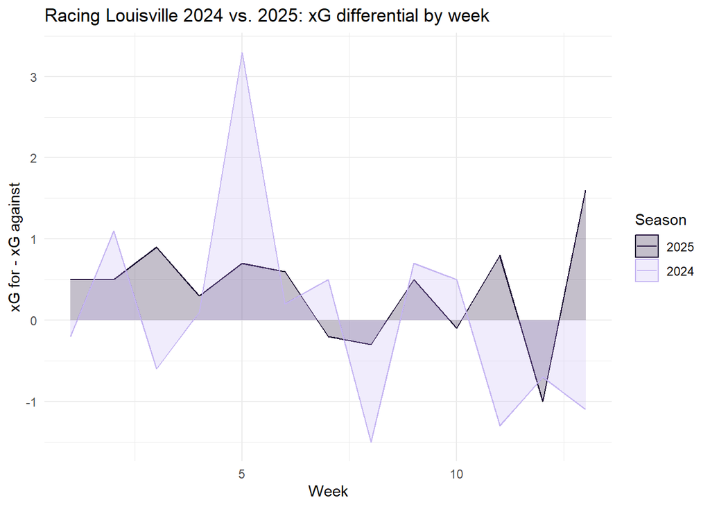

2024 had some high highs and some low lows, and 2025 seems to be an improvement.

| Dependent Variable | t | df | p | d | 95% CI |
| --- | --- | --- | --- | --- | --- |
| xG_Differential | 0.74 | 17.95 | .234 | 0.29 | [-0.48, 1.06] |

As expected, Louisville has had a better xG differential this season, and that’s not an awful p-value.

**Realm 3: Consistency**

This is where the real question is–how consistent is this team, and can we really expect them to keep it up for the rest of the season? Although I’ve been vaguely looking at consistency through line graphs so far, I’m going to now quantify it by performing F-tests that compare the variances of two groups. I will be analyzing goals, goals against, xG, xG against, xG differential, shots for, and shots against.

*Hypothesis test 1: Goals for*

Null hypothesis: There is no difference in the variance between Louisville’s goals scored this season and Louisville’s goals scored last season.

Alternative hypothesis: There is less variance in Louisville’s goals scored this season than there was last season.

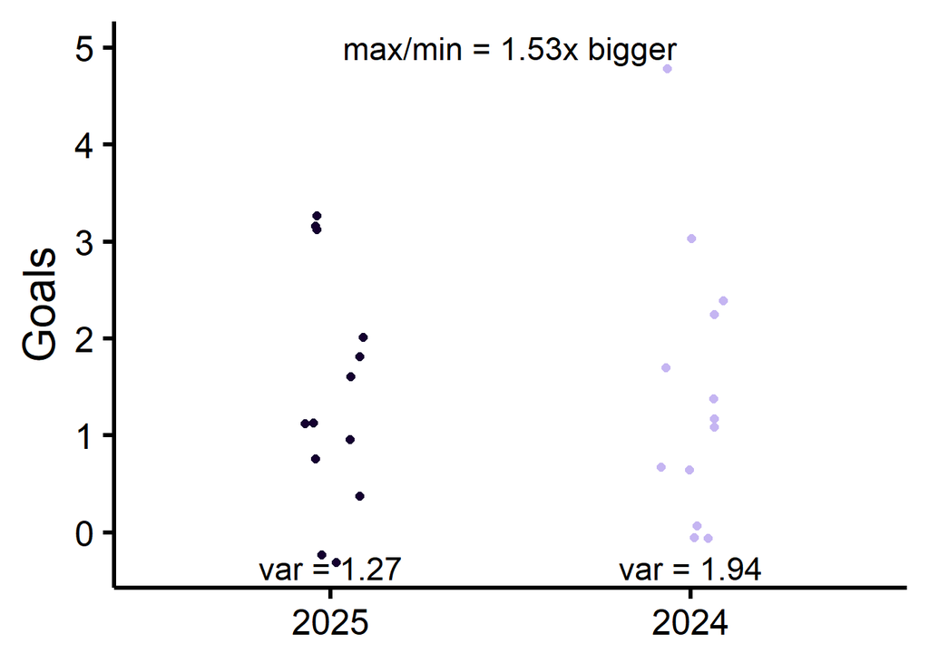

If we plot the variance of these two seasons’ goals scored per game, 2025 appears to have less variance. Let’s take a look at what the F-test says.

| F statistic | p-value | method |
| --- | --- | --- |
| 0.6556291 | 0.2377471 | F test to compare two variances |

How to interpret these results: The F-statistic is essentially a more complicated ratio of variances, where the 2025 variance is the numerator. So we’ll be looking for this number to be under 1. And the p-value is the exact same measure of statistical significance that we’ve been looking at this whole time, with under 0.05 being the gold standard, 0.1 being okay, and between 0.1 and 0.15 sometimes being acceptable.

As a reminder, this was a variable where there was no difference between 2025 and 2024. So this decreased variance is a sign that the goalscoring situation is a little bit better this season than it was last season.

*Hypothesis test 2: Goals against*

Null hypothesis: There is no difference in the variance between Louisville’s goals conceded this season and Louisville’s goals conceded last season.

Alternative hypothesis: There is less variance in Louisville’s goals conceded this season than there was last season.

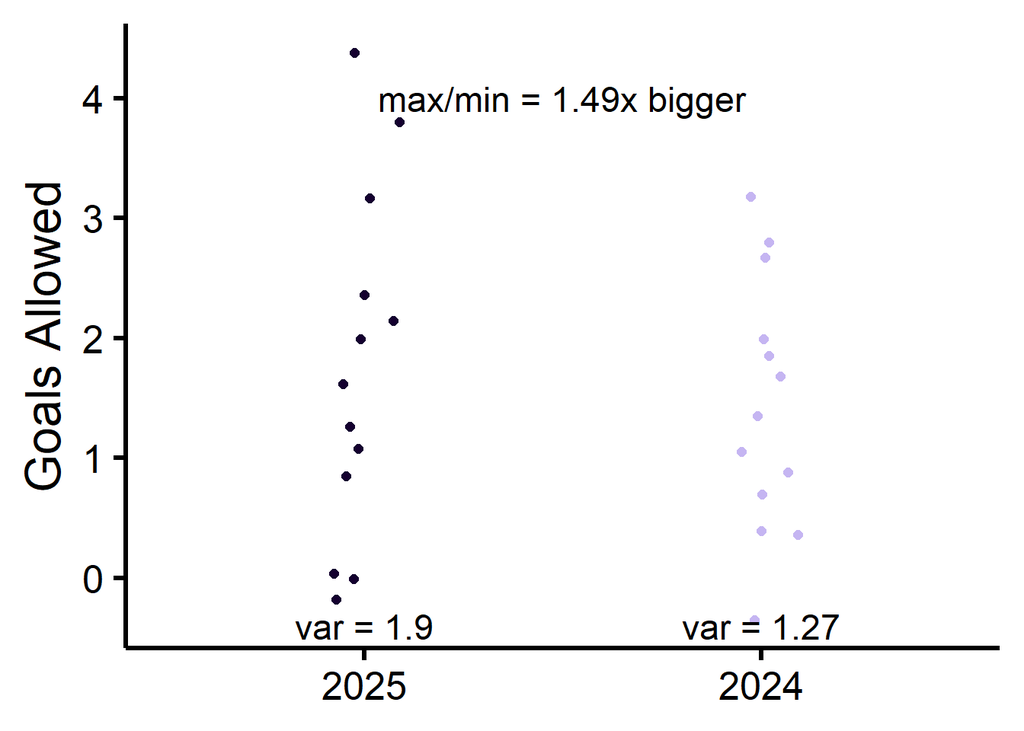

If we plot the variance of these two seasons’ goals allowed per game, 2025 appears to have more variance, which isn’t a great sign.

| F statistic | p-value | method |
| --- | --- | --- |
| 1.494949 | 0.7517079 | F test to compare two variances |

As a reminder, Louisville has conceded more goals this season than did last season, but not statistically significantly so. The increased variance here indicates that they are at least not consistently conceding a lot of goals, which is a win. But it’s not statistically significant, so I don’t think there’s much to read into here.

*Hypothesis test 3: xG for*

Null hypothesis: There is no difference in the variance between Louisville’s xG generated this season and Louisville’s xG generated last season.

Alternative hypothesis: There is less variance in Louisville’s xG generated this season than there was last season.

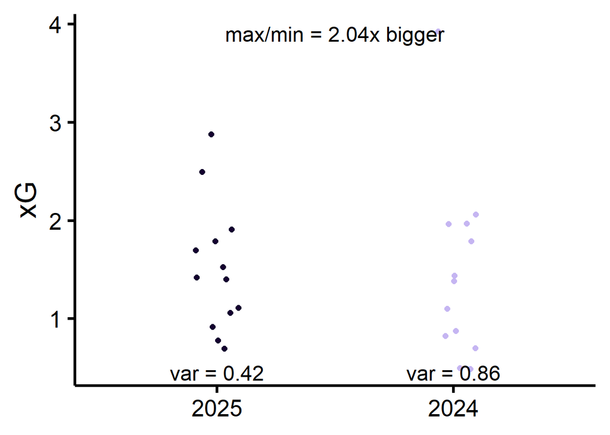

If we plot the variance of these two seasons’ xG generated per game, 2025 appears to have significantly less variance.

| F statistic | p-value | method |
| --- | --- | --- |
| 0.4896869 | 0.1152718 | F test to compare two variances |

As a reminder, Louisville has generated more xG this season than they did last season, but not statistically significantly so. With that context, this decreased variance (and 0.115 p-value!) is a sign that their increased xG production is more impactful than the t-test alone suggests.

*Hypothesis test 4: xG against*

Null hypothesis: There is no difference in the variance between Louisville’s xG conceded this season and Louisville’s xG conceded last season.

Alternative hypothesis: There is less variance in Louisville’s xG conceded this season than there was last season.

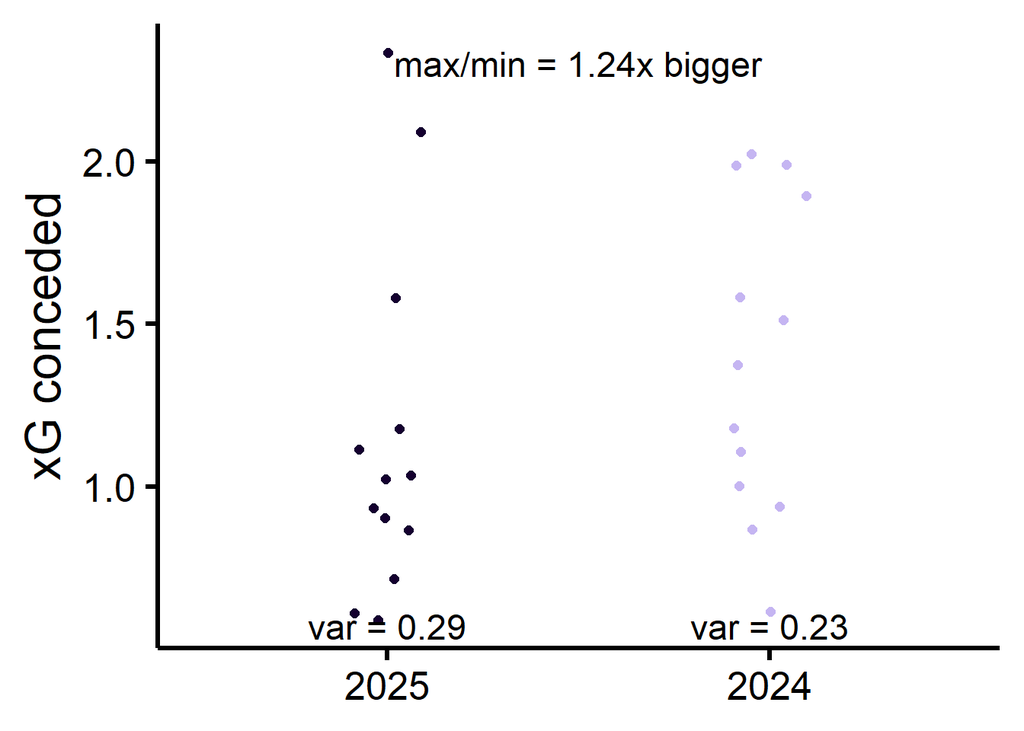

If we plot the variance of these two seasons’ xG conceded per game, both seasons have pretty low variance, but 2024 takes the cake.

| F statistic | p-value | method |
| --- | --- | --- |
| 1.236035 | 0.6402584 | F test to compare two variances |

As a reminder, Louisville has conceded less xG this season than last, and almost statistically significantly so. Their variance is slightly higher this season than the last, but only very slightly, so I wouldn’t read too much into it.

*Hypothesis test 5: xG differential*

Null hypothesis: There is no difference in the variance between Louisville’s xG differential this season and Louisville’s xG differential last season.

Alternative hypothesis: There is less variance in Louisville’s xG differential this season than there was last season.

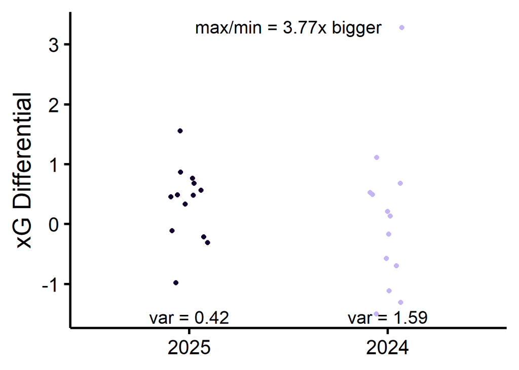

Oh wow. Louisville appears to be generating more xG and conceding less xG at a much more consistent rate than it was last season.

| F statistic | p-value | method |
| --- | --- | --- |
| 0.2652815 | 0.0147266 | F test to compare two variances |

Wow. This is the lowest p-value we’ve seen so far. They might be the real deal. **Racing Louisville is creating and conceding xG at a more consistent rate this season than they were last season**.

*Hypothesis test 6: Shots for*

Null hypothesis: There is no difference in the variance between Louisville’s shots this season and Louisville’s shots last season.

Alternative hypothesis: There is less variance in Louisville’s shots this season than there was last season.

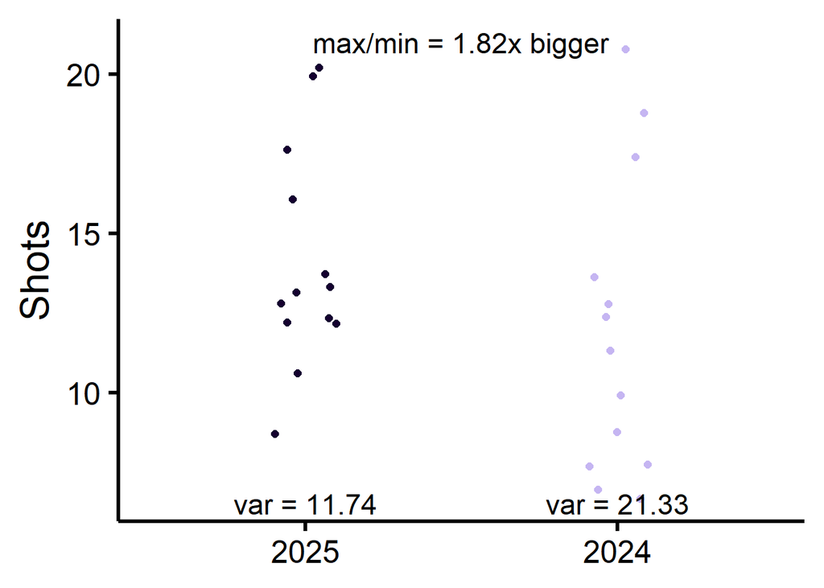

| F statistic | p-value | method |
| --- | --- | --- |
| 0.5504808 | 0.1573366 | F test to compare two variances |

As a reminder, the t-test concluded that Louisville is taking statistically significantly more shots this season than the last (well, almost; the p-value was 0.103). So, that nearly statistically significant p-value combined with this nearly statistically significant p-value makes me believe that Louisville are the real deal compared to last season when looking at shots attempted.

*Hypothesis test 7: Shots against*

Null hypothesis: There is no difference in the variance between Louisville’s shots conceded this season and Louisville’s shots conceded last season.

Alternative hypothesis: There is less variance in Louisville’s shots conceded this season than there was last season.

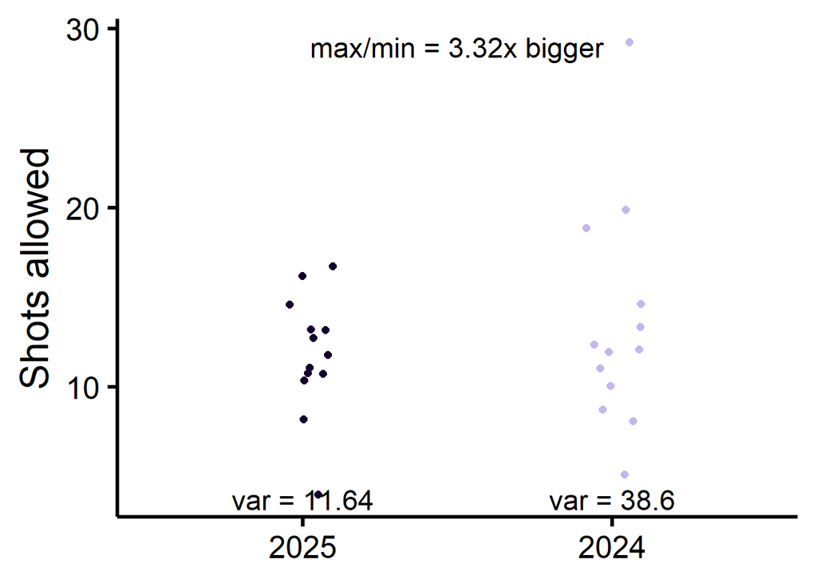

| F statistic | p-value | method |
| --- | --- | --- |
| 0.3015609 | 0.023942 | F test to compare two variances |

And this is now the second-lowest p-value we’ve seen so far. Louisville has allowed fewer shots this season, but not quite statistically significantly so according to the t-test (p = 0.211); the results of the F-test make me believe that maybe it is significant. **Racing Louisville is conceding fewer shots at a more consistent rate this season than they were last season**.

**Conclusion**

Well I’m convinced. On the whole, Louisville does appear to be a better performing team this season than they were last season, and they also seem to be able to put up consistently good performances. Now it’s time to see how they fare against another NWSL team this season. Find out in part 2 [here](https://ajsportstat.github.io/nwsl-2025/team/louisvillept2.html)!

[Back to home](https://ajsportstat.github.io/nwsl-2025)